# Social network analysis on spread of COVID-19

Ashani Wickramasinghe

April 16, 2020

From the World Health Organization - On 31 December 2019, WHO was alerted to several cases of pneumonia in Wuhan City, Hubei Province of China. The virus did not match any other known virus. This raised concern because when a virus is new, we do not know how it affects people.

So daily level information on the affected people can give some interesting insights when it is made available to the broader data science community.

This analysis is regarding the novel Coronavirus and analysis was done to understand the spread of COVID-19 across the world and the impact of other countries on the spread of COVID-19 in Canada.

# Across the World

## Dataset

The data set was downloaded from https://www.kaggle.com/sudalairajkumar/novel-corona-virus-2019-dataset. Here we have data from 22-01-2020 to 10-03-2020

```
##   ï..ID age    sex                       city province country
## 1     1  30   male    Chaohu City, Hefei City    Anhui   China
## 2     2  47   male Baohe District, Hefei City    Anhui   China
## 3     3  49   male High-Tech Zone, Hefei City    Anhui   China
## 4     4  47 female High-Tech Zone, Hefei City    Anhui   China
## 5     5  50 female Feidong County, Hefei City    Anhui   China
## 6     6 N/A    N/A                 Lu'an City    Anhui   China
##   wuhan.0._not_wuhan.1.  latitude  longitude geo_resolution
## 1                     1  31.64696   117.7166         admin3
## 2                     1  31.77863   117.3319         admin3
## 3                     1 31.828313 117.224844          point
## 4                     1 31.828313 117.224844          point
## 5                     1  32.00123   117.5681         admin3
## 6                     1  31.75941   116.3151         admin2
##   date_onset_symptoms date_admission_hospital date_confirmation  symptoms
## 1          18.01.2020              20.01.2020        22.01.2020
## 2          10.01.2020              21.01.2020        23.01.2020
## 3          15.01.2020              20.01.2020        23.01.2020
## 4          17.01.2020              20.01.2020        23.01.2020
## 5          10.01.2020              21.01.2020        23.01.2020
## 6                                                    24.01.2020 pneumonia
##   lives_in_Wuhan travel_history_dates  travel_history_location
## 1            yes           17.01.2020                    Wuhan
## 2             no           10.01.2020  Luzhou Hunan, via Wuhan
## 3             no           10.01.2020 Yinzhou Hunan, via Wuhan
## 4             no
## 5             no           07.01.2020                    Wuhan
## 6
##   reported_market_exposure
## 1
## 2
## 3
## 4
## 5
## 6
##                                   additional_information
## 1
## 2
## 3
## 4                          contacted with confirmed case
```

[output cut: 22 more lines]

```
## 6
##         location           admin3     admin2 admin1 country_new admin_id
## 1                     Chaohu City Hefei City  Anhui       China   340181
## 2                  Baohe District Hefei City  Anhui       China   340111
## 3 High-Tech Zone Shushan District Hefei City  Anhui       China   340104
## 4 High-Tech Zone Shushan District Hefei City  Anhui       China   340104
## 5                  Feidong County Hefei City  Anhui       China   340122
## 6                                 Lu'an City  Anhui       China   341500
##   data_moderator_initials  X X.1 X.2 X.3 X.4 X.5 X.6 X.7 X.8 X.9 X.10 X.11
## 1                         NA  NA  NA  NA  NA  NA  NA  NA  NA  NA   NA   NA
## 2                         NA  NA  NA  NA  NA  NA  NA  NA  NA  NA   NA   NA
## 3                         NA  NA  NA  NA  NA  NA  NA  NA  NA  NA   NA   NA
## 4                         NA  NA  NA  NA  NA  NA  NA  NA  NA  NA   NA   NA
## 5                         NA  NA  NA  NA  NA  NA  NA  NA  NA  NA   NA   NA
## 6                         NA  NA  NA  NA  NA  NA  NA  NA  NA  NA   NA   NA
```

## Data Cleaning

In this data set there was some data that does not represent any information about the patients’ travel history. Then by analyzing a few cells of the “Additional information” column I could understand that the patient has not traveled recently and he or she was infected by their family member or friends. Because of that in those cases the country in which the patient was found and the country that patient traveled will be the same. Some data had missing values for both “Travel_location” and “Additional information”. So those rows were deleted. Finally, a new data set was created, where “Travel_location” was considered as the “Source”, “country” was considered as the “Target” and the number of patients who traveled between these countries were considered as “Weight” variable. This was used to create social networks.

```
##      Source    Target Weight
## 1 Australia Australia      1
## 2    Canada    Canada      4
## 3     China Australia     13
## 4     China   Belgium      1
## 5     China  Cambodia      1
## 6     China    Canada      5
```

## Social Network Graphs

In these networks’ nodes were considered as countries and link was created when a person traveled from one country to another. Here “igraph” package in r, was used to create the first two graphs and the last graph was created using “networkx” package in python.

### Indegree network

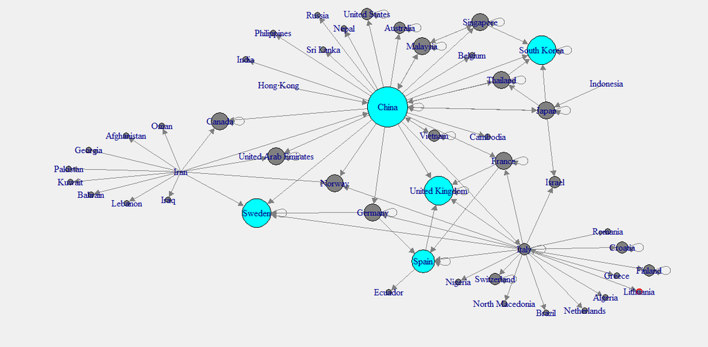

Here cyan color indicates the nodes with higher in-degree. From the higher in degree value we can identify the main countries which found many patients who came from different other countries.

### Outdegree network

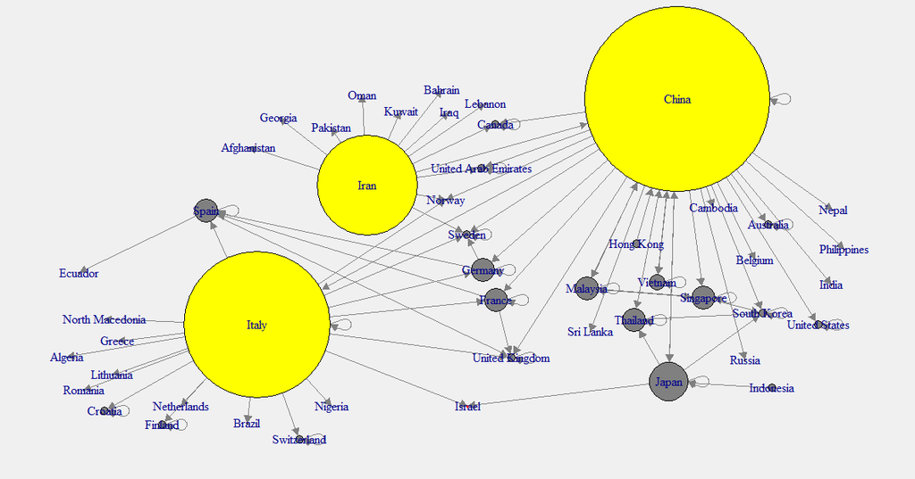

Here yellow color indicates the nodes with higher out-degree. From the higher out-degree value we can identify the main countries in which many patients traveled to many other countries. So we can say these are the main countries which spread this virus to other countries.

### Network of Patients and countries

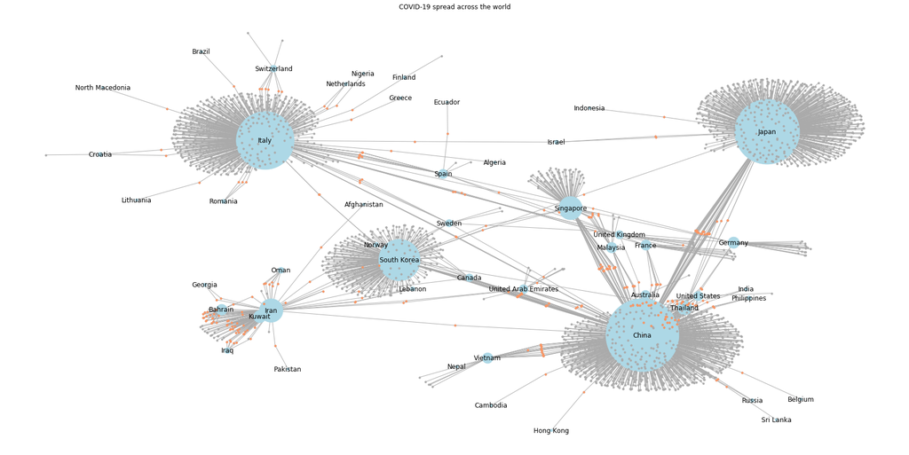

Here blue color nodes indicate countries, ash color nodes indicate locally infected patients and orange color nodes indicate the patients who traveled from one country to another.

# Canada

In this analysis we are going to check the impact of other countries on the spread of COVID-19 in Canada.

## Dataset

Basic dataset was downloaded from https://github.com/ishaberry/Covid19Canada/blob/master/codebook.csv. Here we have data from 25-01-2020 to 05-04-2020

```
##   case_id provincial_case_id   age    sex     health_region province
## 1       1                  1 50-59   Male           Toronto  Ontario
## 2       2                  2 50-59 Female           Toronto  Ontario
## 3       3                  1 40-49   Male Vancouver Coastal       BC
## 4       4                  3 20-29 Female  Middlesex-London  Ontario
## 5       5                  2 50-59 Female Vancouver Coastal       BC
## 6       6                  3 30-39   Male Vancouver Coastal       BC
##   country date_report report_week travel_yn travel_history_country
## 1  Canada  25-01-2020  19-01-2020         1                  China
## 2  Canada  27-01-2020  26-01-2020         1                  China
## 3  Canada  28-01-2020  26-01-2020         1                  China
## 4  Canada  31-01-2020  26-01-2020         1                  China
## 5  Canada    4/2/2020    2/2/2020         0
## 6  Canada    6/2/2020    2/2/2020         1                  China
##   locally_acquired
## 1
## 2
## 3
## 4
## 5    Close Contact
## 6
##                                                                                                                                                                                                                                                 case_source
## 1 (1) https://news.ontario.ca/mohltc/en/2020/01/ontario-confirms-first-case-of-wuhan-novel-coronavirus.html ;(2) https://globalnews.ca/news/6497313/coronavirus-timeine-cases-canada/; (3) https://globalnews.ca/news/6462626/coronavirus-toronto-hospital/
## 2                                                          (1) https://news.ontario.ca/mohltc/en/2020/01/ontario-confirms-second-presumptive-case-of-wuhan-novel-coronavirus.html ;(2) https://globalnews.ca/news/6497313/coronavirus-timeine-cases-canada/
## 3                                                                                                                                                                                                       https://news.gov.bc.ca/releases/2020HLTH0015-000151
## 4                                                                        (1) https://news.ontario.ca/mohltc/en/2020/01/ontario-confirms-third-case-of-2019-novel-coronavirus.html ;(2) https://globalnews.ca/news/6497313/coronavirus-timeine-cases-canada/
## 5                                                                                                                                                                                                       https://news.gov.bc.ca/releases/2020HLTH0023-000222
## 6                                                                                                                                                                                                       https://news.gov.bc.ca/releases/2020HLTH0025-000236
##                                                         additional_info
## 1
## 2                                              Travel and Close Contact
## 3
## 4
## 5 The individual had close contact with family visitors from Wuhan city
## 6
##   additional_source method_note
## 1                             0
## 2                             0
## 3                            NA
## 4                             0
## 5                            NA
## 6                            NA
```

## Data Cleaning

Here we have considered each state of Canada separately. Some patients did not have any travel information and some did not report the country they traveled. So they were considered as locally infected cases. Also according to travel history some people had visited more than one country. So multiple rows were added for the same patient by splitting travel_history_country variable. Finally, a new data set was created, where “Travel_location” was considered as the “Source”, “province” was considered as the “Target” and the number of patients who traveled between these locations were considered as “Weight” variable. This was used to create social networks.

```
##          Source  Target Weight
## 1   Netherlands Alberta      1
## 2        Turkey Alberta      1
## 3       Alberta Alberta     16
## 4        Cruise Alberta      4
## 5       Ukraine Alberta      1
## 6 United States Alberta      3
```

## Social Networks

In these networks’ nodes were considered as countries and states of Canada and link was created when a person traveled from one country to a state of Canada. Here “igraph” package in r, was used to create the first two graphs and the last graph was created using “networkx” package in python.

### Indegree Network of Canada

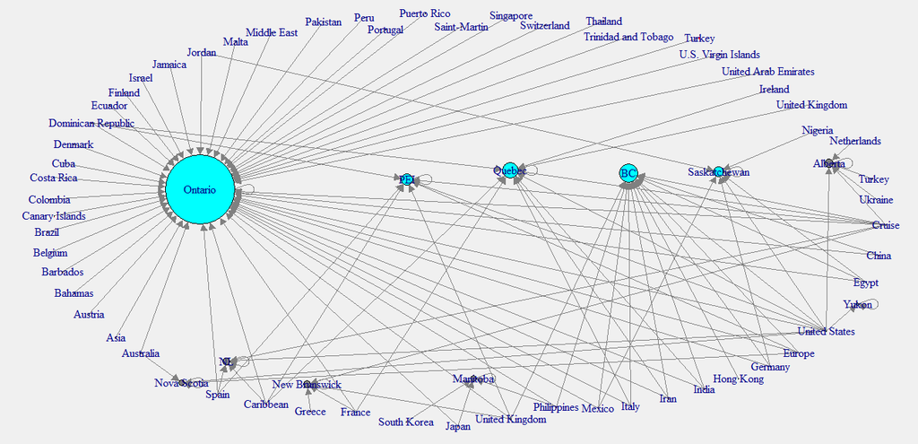

Here cyan color indicates the nodes with higher in-degree. From the higher in degree value we can identify the main states which found many patients who came from different countries. According to this plot, a significant number of patients from many countries have entered to Ontario.

### Outdegree Network of Canada

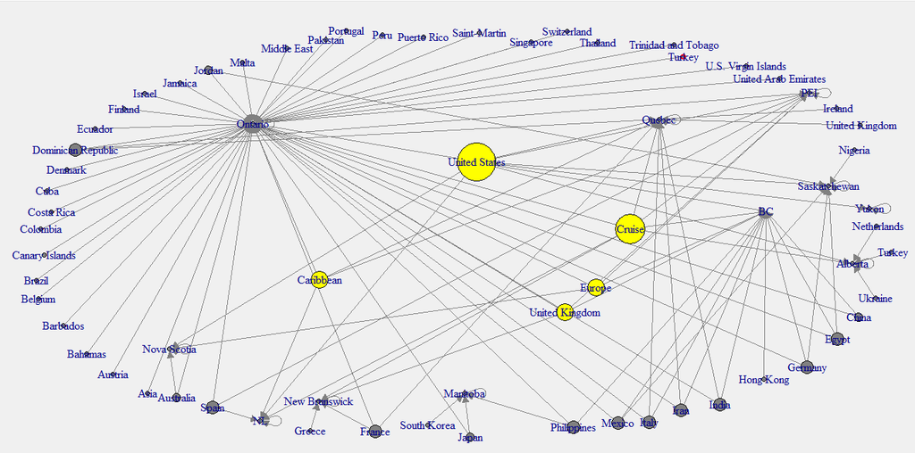

Here yellow color indicates the nodes with higher out-degree. From the higher out-degree value we can identify the main countries in which many patients traveled to Canada. So these are the main countries that spread this virus to Canada. People who traveled on Grand Princess Cruise has also affected the spread of COVID in Canada.

### Network of Patients, Countries and States of Canada

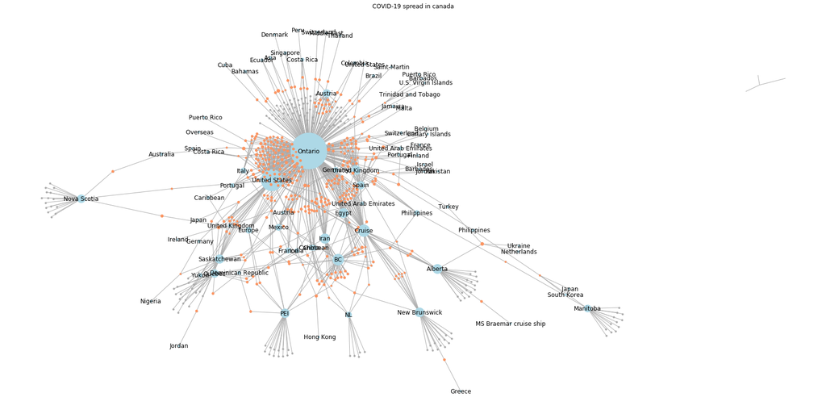